# Disp Validation

```python
%matplotlib inline
from resolutionPlottingData import *

filename = "/a/home/tehanu/dribeiro/Analysis/CrabSim/runlists/Classes/Results_geo.txt"
d=data_struc(filename)
p=plotResolutions(d)
filename2 = "/a/home/tehanu/dribeiro/Analysis/CrabSim/runlists/Classes/Results_disp_new.txt"
d_dnew=data_struc(filename2)
p_dnew=plotResolutions(d_dnew)
filename3 = "/a/home/tehanu/dribeiro/Analysis/CrabSim/runlists/Classes/Results_disp_old.txt"
d_dold=data_struc(filename3)
p_dold=plotResolutions(d_dold)

p.set_linestyle('-.')
p_dnew.set_linestyle(':')
p_dold.set_linestyle('--')

noise=350
```

Comparison of Geo, Disp new and Disp old Methods for event reconstructionThis is done by plotting the resolution per energy bin for various simulations. The resolution is the 68% containment radius of the data, from the source center. Geo Method:First: compare the calculation of resolution using 2 methods available: RMS and Res methodsRMS is calculated by calculating STD of the arrival angles.Res is calculated by arranging all the events (those in the specified energy bin) in order of angle, then picking the 68% bin.Looking at wobble = 000

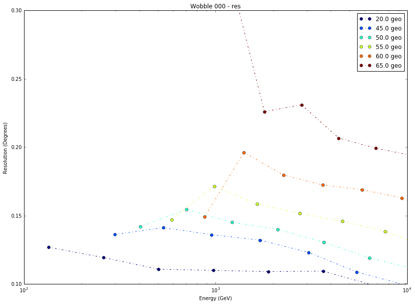

```python
p.vary_zeniths(3,wobble=0, noise=noise,resolution="res")
plt.title("Wobble 000 - res")
```

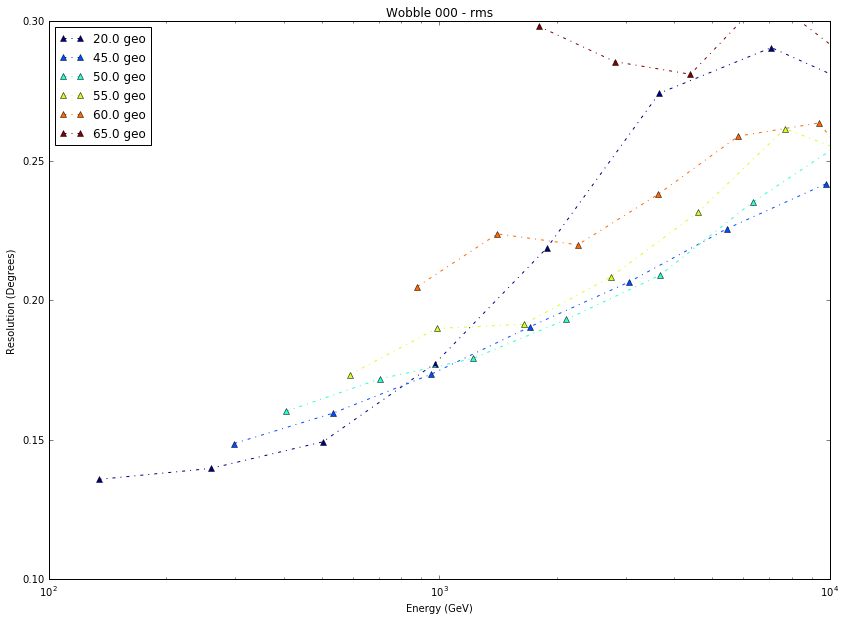

```python
p.vary_zeniths(4,wobble=0, noise=noise,marker='^',resolution="rms")
plt.title("Wobble 000 - rms")
plt.show()
```

Looking at wobble = 0.50

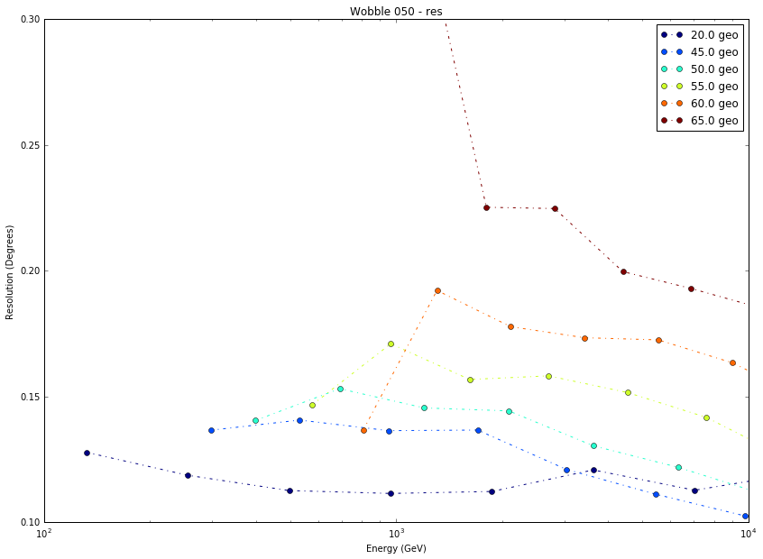

```python
p.vary_zeniths(1,wobble=50,noise=noise,resolution="res")
plt.title("Wobble 050 - res")
```

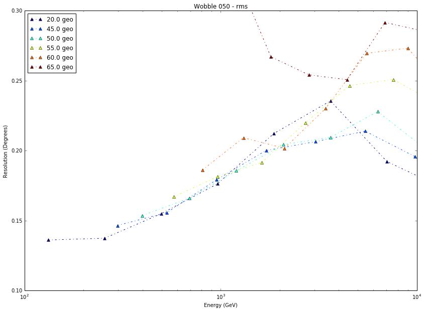

```python
p.vary_zeniths(2,wobble=50,noise=noise,marker='^',resolution='rms')
plt.title("Wobble 050 - rms")
plt.show()
```

Here are both wobbles on same plot:

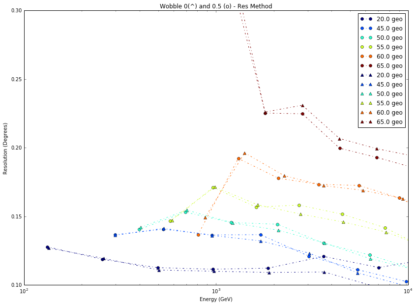

```python
plt.figure(1,figsize=[14,10])
p.vary_zeniths(1,noise=noise)
p.vary_zeniths(1,wobble=0, noise=noise,marker='^')
plt.title("Wobble 0(^) and 0.5 (o) - Res Method")
plt.show()
```

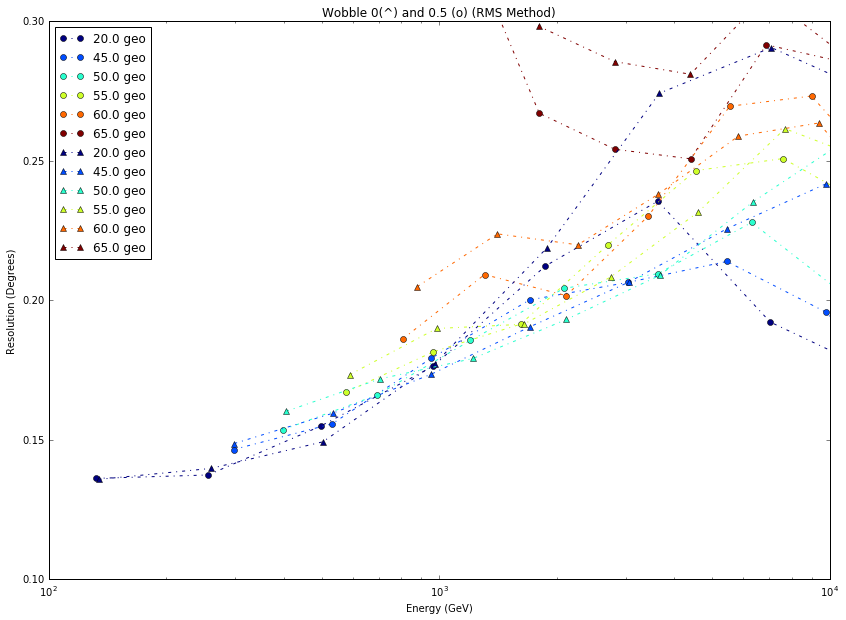

```python
plt.figure(2,figsize=[14,10])
p.vary_zeniths(2,noise=noise,resolution="rms")
p.vary_zeniths(2,wobble=0, noise=noise,marker='^',resolution="rms")
plt.title("Wobble 0(^) and 0.5 (o) (RMS Method)")
plt.show()
```

Higher wobbles for GEO method (all res method):

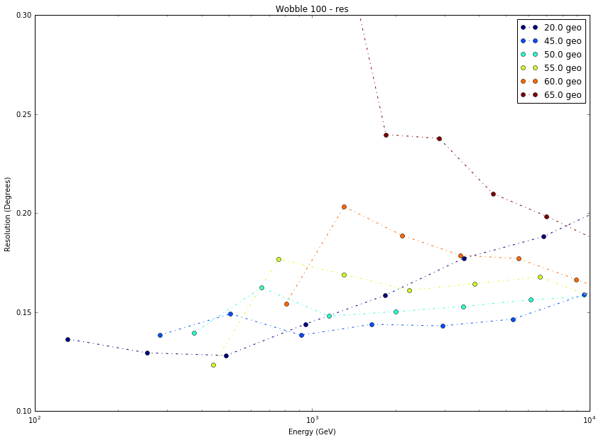

```python
p.vary_zeniths(4,wobble=100, noise=noise)
plt.title("Wobble 100 - res")
plt.show()
```

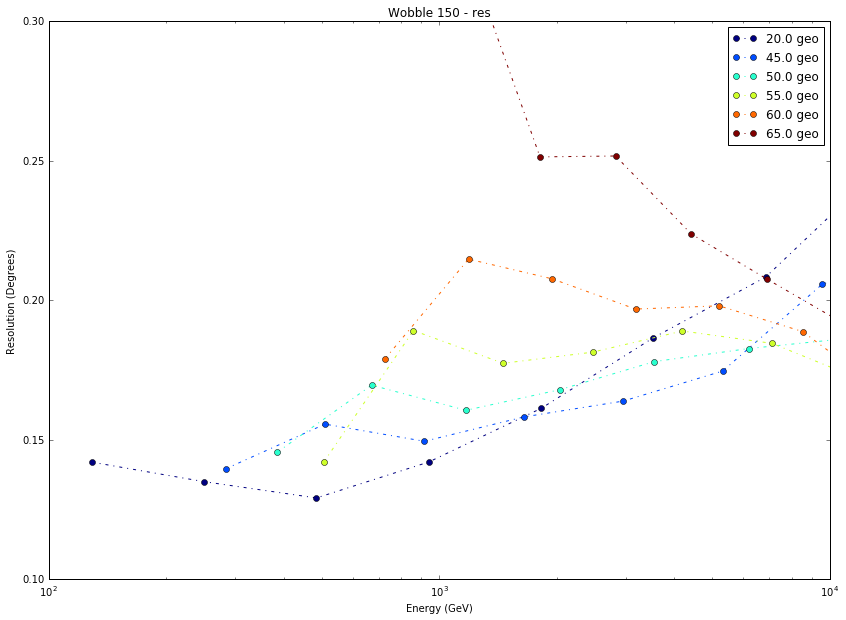

```python
p.vary_zeniths(5,wobble=150, noise=noise)
plt.title("Wobble 150 - res")
plt.show()
```

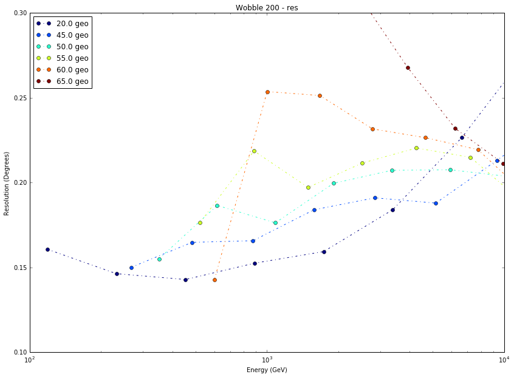

```python
p.vary_zeniths(6,wobble=200, noise=noise)
plt.title("Wobble 200 - res")
plt.show()
```

Checking the higher wobble for the RMS method as well

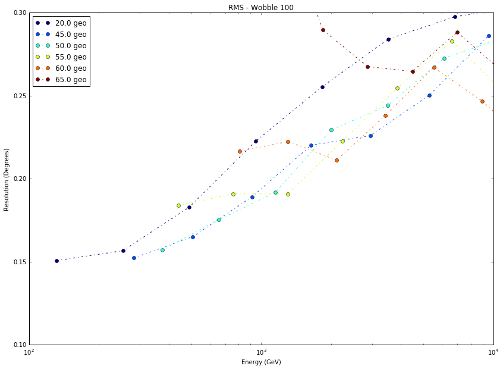

```python
p.vary_zeniths(4,wobble=100,noise=noise,resolution="rms")
plt.title("RMS - Wobble 100")
plt.show()
```

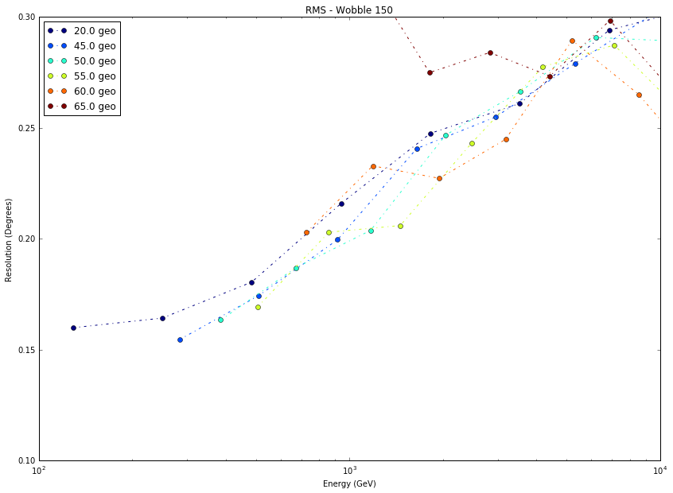

```python
p.vary_zeniths(5,wobble=150, noise=noise,resolution="rms")
plt.title("RMS - Wobble 150")
plt.show()
```

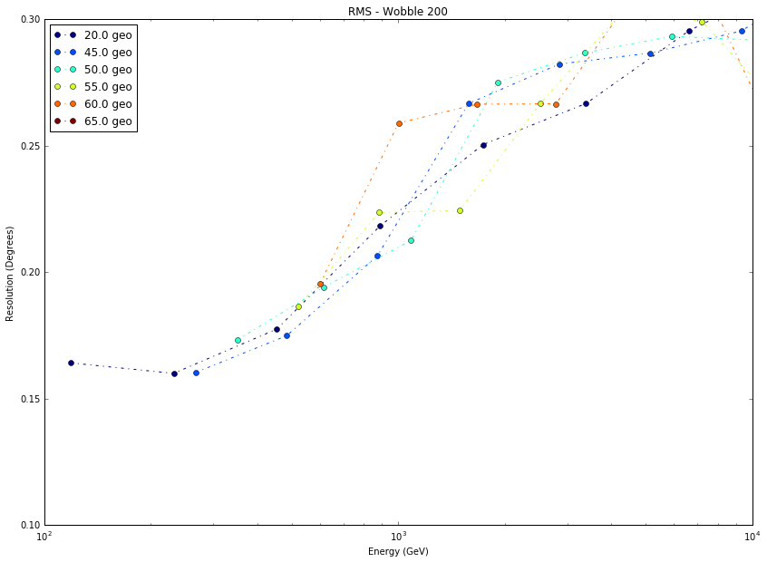

```python
p.vary_zeniths(6,wobble=200, noise=noise,resolution="rms")
plt.title("RMS - Wobble 200")
plt.show()
```

Disp_new:All wobbles, using res method

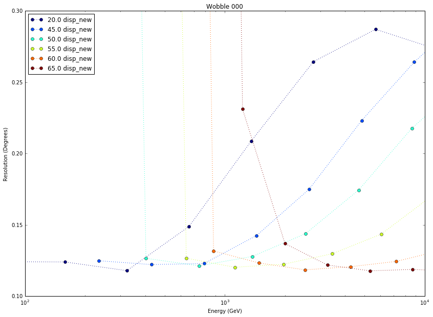

```python
p_dnew.vary_zeniths(1,wobble=0  ,noise=noise,resolution="res")
#p.vary_zeniths(1,wobble=0  ,noise=noise,resolution="res", marker='^')
plt.title("Wobble 000")
plt.show()
```

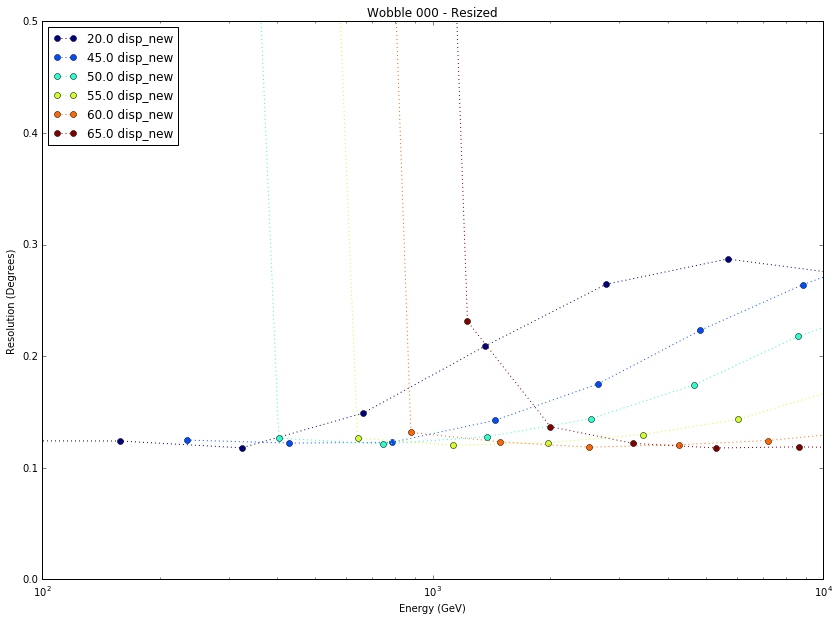

```python
p_dnew.vary_zeniths(2,wobble=0  ,noise=noise,resolution="res")
#p.vary_zeniths(2,wobble=0  ,noise=noise,resolution="res", marker='^')
plt.ylim([0,0.5])
plt.title("Wobble 000 - Resized")
plt.show()
```

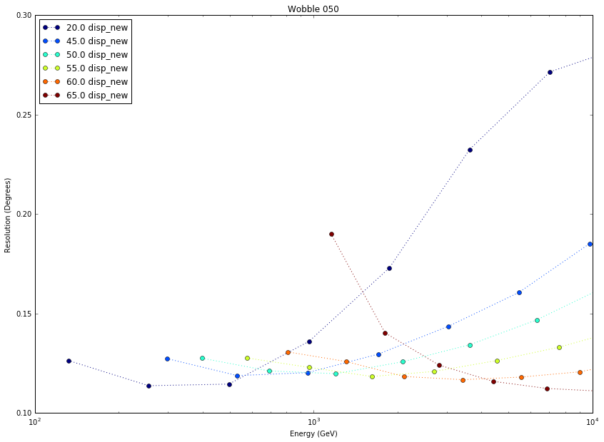

```python
p_dnew.vary_zeniths(3,wobble=50 ,noise=noise,resolution="res")
#p.vary_zeniths(3,wobble=50 ,noise=noise,resolution="res", marker='^')
plt.title("Wobble 050")
plt.show()
```

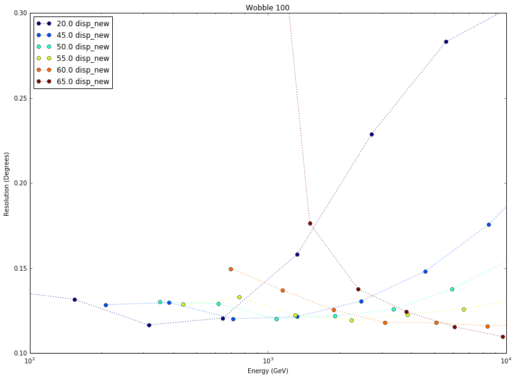

```python
p_dnew.vary_zeniths(4,wobble=100,noise=noise,resolution="res")
#p.vary_zeniths(4,wobble=100,noise=noise,resolution="res", marker='^')
plt.title("Wobble 100")
plt.show()
```

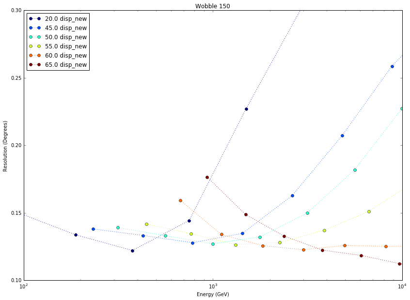

```python
p_dnew.vary_zeniths(5,wobble=150,noise=noise,resolution="res")
#p.vary_zeniths(5,wobble=150,noise=noise,resolution="res", marker='^')
plt.title("Wobble 150")
plt.show()
```

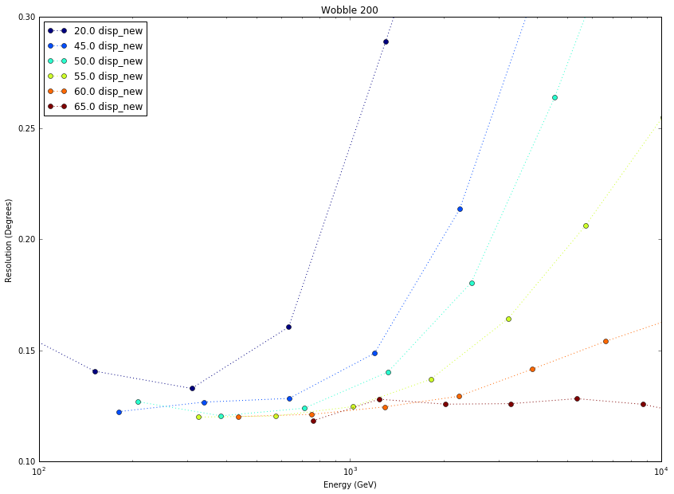

```python
p_dnew.vary_zeniths(6,wobble=200,noise=noise,resolution="res")
#p.vary_zeniths(6,wobble=200,noise=noise,resolution="res", marker='^')
plt.title("Wobble 200")
plt.show()
```

Disp Old:All wobbles, using res method

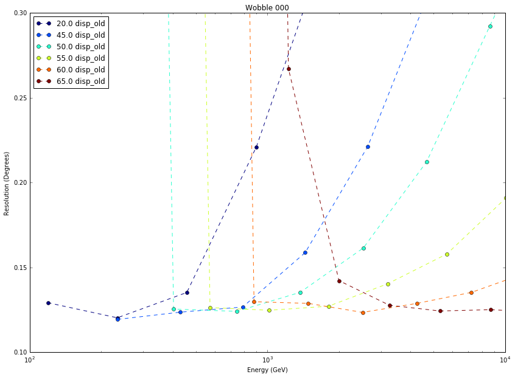

```python
# p_dnew.vary_zeniths(1,wobble=0  ,noise=noise,resolution="res")
# p.vary_zeniths(1,wobble=0  ,noise=noise,resolution="res", marker='^')
p_dold.vary_zeniths(1,wobble=0  ,noise=noise,resolution="res", marker='o')
plt.title("Wobble 000")
plt.show()
```

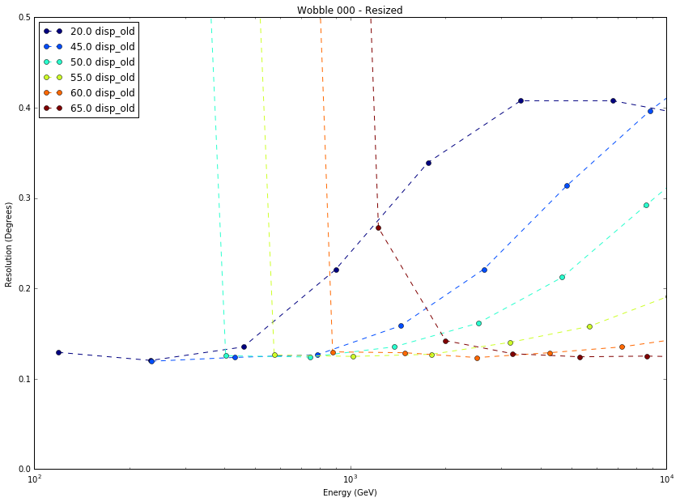

```python
# p_dnew.vary_zeniths(2,wobble=0  ,noise=noise,resolution="res")
# p.vary_zeniths(2,wobble=0  ,noise=noise,resolution="res", marker='^')
p_dold.vary_zeniths(2,wobble=0  ,noise=noise,resolution="res", marker='o')
plt.ylim([0,0.5])
plt.title("Wobble 000 - Resized")
plt.show()
```

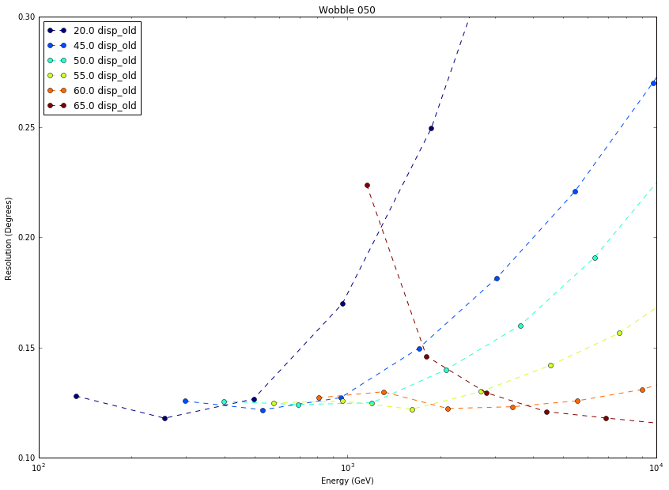

```python
# p_dnew.vary_zeniths(3,wobble=50 ,noise=noise,resolution="res")
# p.vary_zeniths(3,wobble=50 ,noise=noise,resolution="res", marker='^')
p_dold.vary_zeniths(3,wobble=50 ,noise=noise,resolution="res", marker='o')
plt.title("Wobble 050")
plt.show()
```

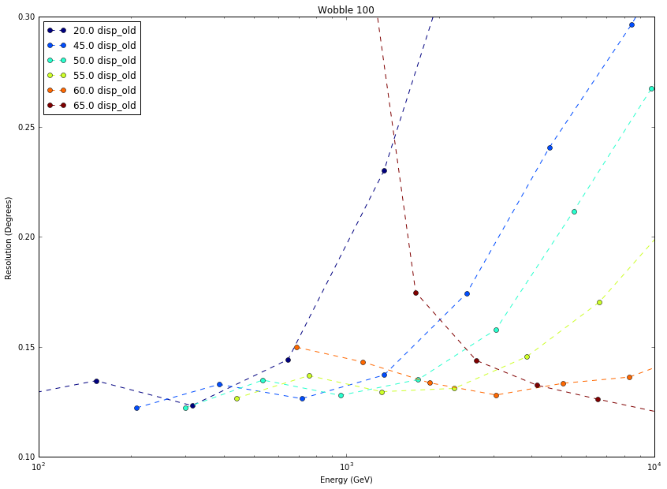

```python
# p_dnew.vary_zeniths(4,wobble=100,noise=noise,resolution="res")
# p.vary_zeniths(4,wobble=100,noise=noise,resolution="res", marker='^')
p_dold.vary_zeniths(4,wobble=100,noise=noise,resolution="res", marker='o')
plt.title("Wobble 100")
plt.show()
```

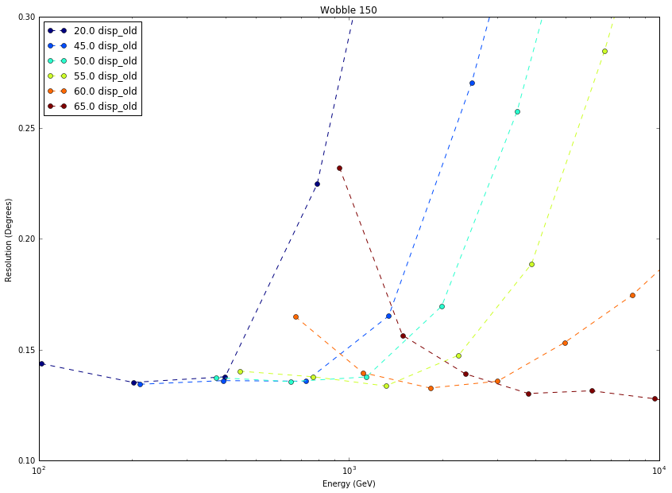

```python
# p_dnew.vary_zeniths(5,wobble=150,noise=noise,resolution="res")
# p.vary_zeniths(5,wobble=150,noise=noise,resolution="res", marker='^')
p_dold.vary_zeniths(5,wobble=150,noise=noise,resolution="res", marker='o')
plt.title("Wobble 150")
plt.show()
```

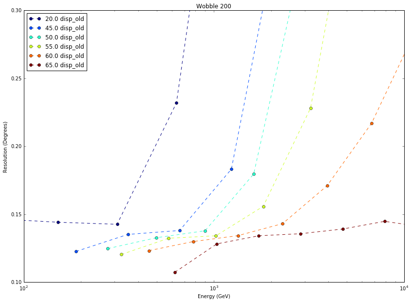

```python
# p_dnew.vary_zeniths(6,wobble=200,noise=noise,resolution="res")
# p.vary_zeniths(6,wobble=200,noise=noise,resolution="res", marker='^')
p_dold.vary_zeniths(6,wobble=200,noise=noise,resolution="res", marker='o')
plt.title("Wobble 200")
plt.show()
```

Geo:All wobbles, using res method

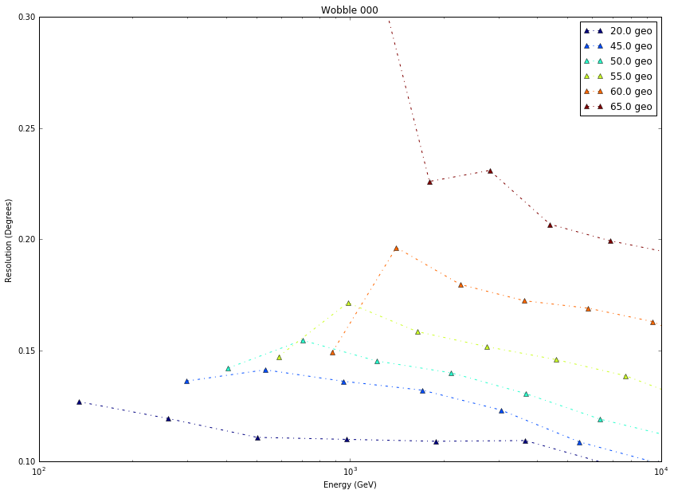

```python
#p_dnew.vary_zeniths(1,wobble=0  ,noise=noise,resolution="res")
p.vary_zeniths(1,wobble=0  ,noise=noise,resolution="res", marker='^')
#p_dold.vary_zeniths(1,wobble=0  ,noise=noise,resolution="res", marker='*')
plt.title("Wobble 000")
plt.show()
```

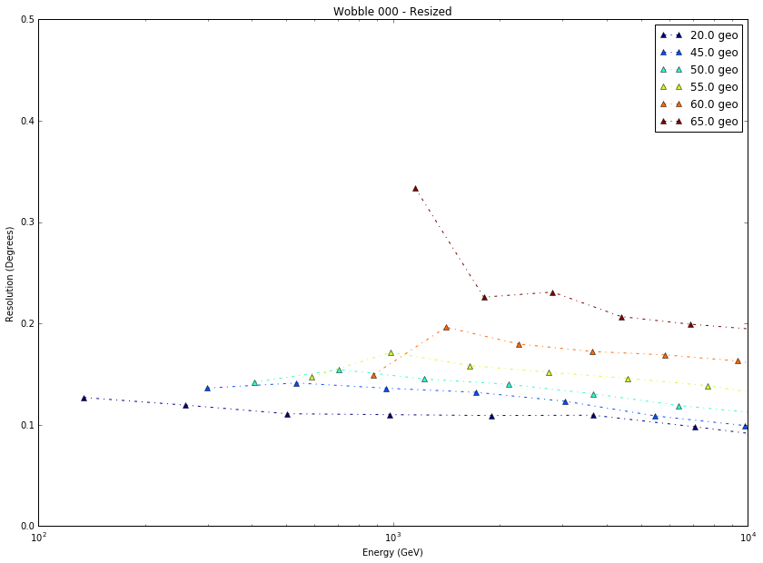

```python
# p_dnew.vary_zeniths(2,wobble=0  ,noise=noise,resolution="res")
p.vary_zeniths(2,wobble=0  ,noise=noise,resolution="res", marker='^')
#p_dold.vary_zeniths(2,wobble=0  ,noise=noise,resolution="res", marker='*')
plt.ylim([0,0.5])
plt.title("Wobble 000 - Resized")
plt.show()
```

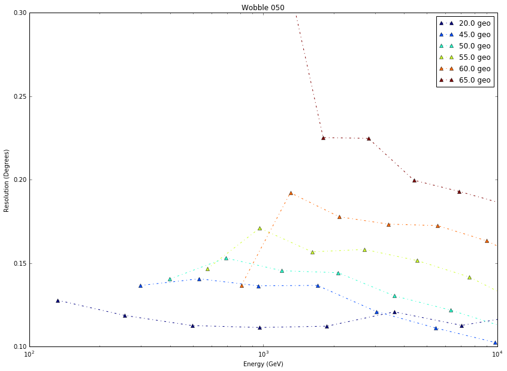

```python
p.vary_zeniths(6,wobble=50,noise=noise,resolution="res", marker='^')
plt.title("Wobble 050")
plt.show()
```

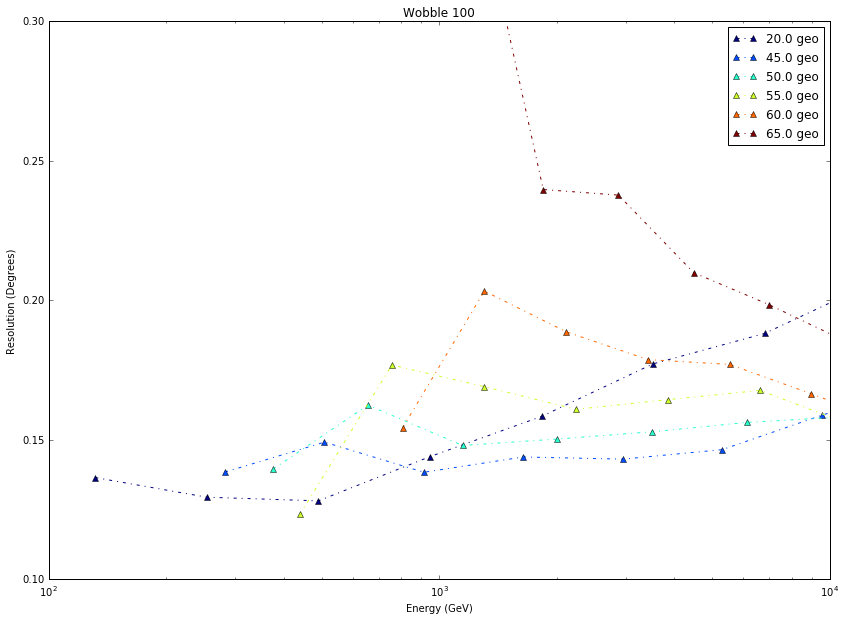

```python
p.vary_zeniths(6,wobble=100,noise=noise,resolution="res", marker='^')
plt.title("Wobble 100")
plt.show()
```

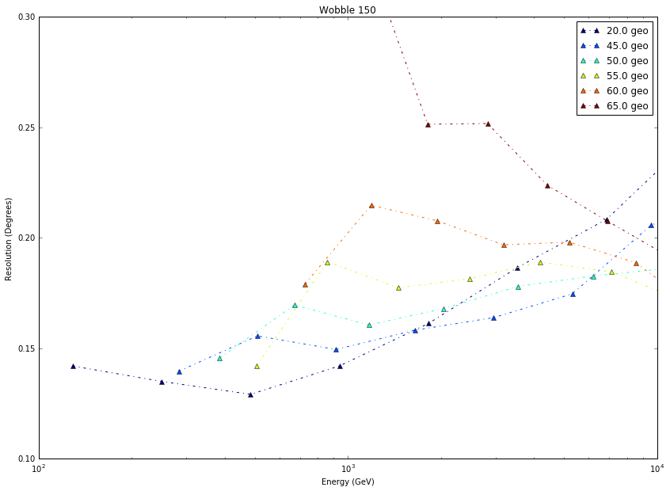

```python
p.vary_zeniths(6,wobble=150,noise=noise,resolution="res", marker='^')
plt.title("Wobble 150")
plt.show()
```

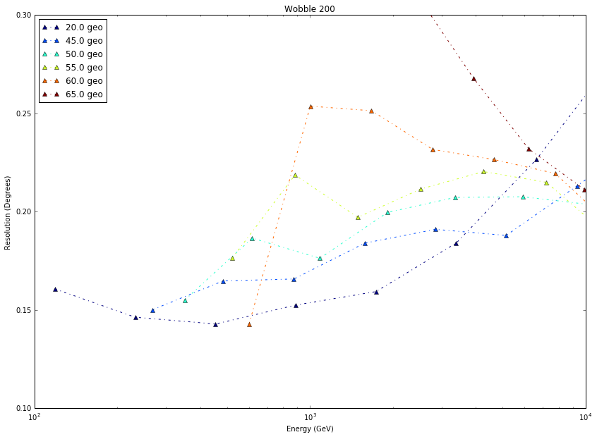

```python
p.vary_zeniths(6,wobble=200,noise=noise,resolution="res", marker='^')
plt.title("Wobble 200")
plt.show()
```

Some Practice commands

```
(0.1, 0.3)
```

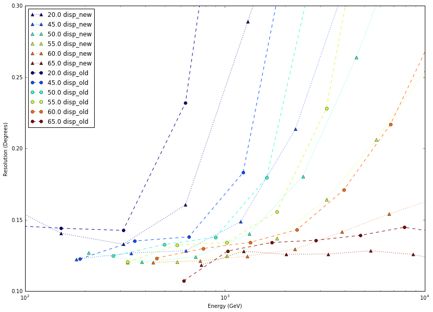

```python
p_dnew.vary_zeniths(1,wobble=200,noise=noise, resolution="res",marker="^")
p_dold.vary_zeniths(1,wobble=200,noise=noise, resolution="res",marker="o")
plt.xlim([1e2,1e4])
plt.ylim([0.1,0.30])

# p.vary_zeniths(1,wobble=50,noise=noise, resolution="res",marker="*")
```